# Danish Kings Portfolio 2

Amanda Gulstad Pedersen

2025-26-05

## Load library and kings streadsheet

The spreadsheet DanishMonarchs.csv is separated by semi colon.

2. Create a `kings` object in R with the different functions below and inspect the different outputs.
- `read.csv()`
- `read_csv()`
- `read.csv2()`
- `read_csv2()`

```r
library(tidyverse)
kings1 <- read.csv("DataKings/DanishMonarchs.csv", na = c("NA"))

kings2 <- read_csv("DataKings/DanishMonarchs.csv", na = c("NA"))
kings3 <- read.csv2("DataKings/DanishMonarchs.csv", na = c("NA"))

kings4 <- read_csv2("DataKings/DanishMonarchs.csv", na = c("NA"))
```

```
## ℹ Using "','" as decimal and "'.'" as grouping mark. Use `read_delim()` for more control.
```

Answer: 1. The function using an underscore (_) is from the TidyVerse package, while using full stop (.) is a part of base R. Weather to use 1 or 2 depends on which separator the spreadsheet has. As my spreadsheet is separated by a semicolon, using the function read_csv2 is the best option.

2. The result of running `class()` on the `kings` object created with a tidyverse function (which would be kings4) is: [1] “spec_tbl_df” “tbl_df” “tbl” “data.frame”
3. Using the function ncol(), we can se the spreadsheet has 5 columns. If using the wrong function for the seperater, the spreadsheet is read as having only 1.
4. Using the function glimpse() we can see a snippet of the dataset and how R interprets the data.

```r
kings <- kings4

class(kings)
```

```
## [1] "spec_tbl_df" "tbl_df"      "tbl"         "data.frame"
```

```r
ncol(kings)
```

```
## [1] 5
```

```r
glimpse(kings)
```

```
## Rows: 54
## Columns: 5
## $ monarch          <chr> "gorm_d_gamle", "harald_1", "svend_1", "harald_2", "k…
## $ birth_year       <dbl> 908, NA, NA, NA, 995, 1020, 1024, 1020, 1040, 1042, 1…
## $ death_year       <dbl> 958, 987, 1014, 1018, 1035, 1042, 1047, 1076, 1080, 1…
## $ start_reign_year <dbl> NA, NA, 1000, 1014, 1018, 1035, 1042, 1047, 1074, 108…
## $ end_reign_year   <dbl> 958, 987, 1014, 1018, 1035, 1042, 1047, 1074, 1080, 1…
```

## Calculate the duration of reign for all the kings using the mutate function

Here, I am using the mutate function to create a new column showing the duration of reign for each monarch. I am using !is.na so it only calculates the reign duration of monarchs where both start and end of reign year is known.

```r
kings <- kings %>%
  filter(!is.na(end_reign_year), !is.na(start_reign_year)) %>%
  mutate(duration = end_reign_year - start_reign_year)
```

## Calculate the average duration of reign for all rulers

```r
kings_gennemsnit <- kings %>%
  summarize(gennemsnit_duration = mean(duration, na.rm=TRUE))
```

## How many and which kings enjoyed a longer-than-average duration of reign?

Using the filter() function to create a new object that shows the kings with a longer reign than average. It shows that 25 kings had a reign longer than the average of 19 years.

```r
kings_over_gennemsnit <- filter(kings, duration > mean(duration, na.rm=TRUE))

count(kings_over_gennemsnit)
```

```
## # A tibble: 1 × 1
##       n
##   <int>
## 1    25
```

To create a new object which shows the top 3 longest ruling monarchs, i first use the arrange function to arrange the kings in descending order, and using the slice function, i remove all but the first 3 monarchs. With the use of mutate, we can add a 7th column that shows the duration in days.

```r
Top_3 <- kings %>%
  arrange(desc(duration)) %>%
  slice(1:3) %>%
  mutate(days = duration * 365.25)
```

## Challenge: Plot the kings’ duration of reign through time

Using ggplot we can create visuals of the monarch’s duration of reign with two different functions, geom_point and geoom_smooth.

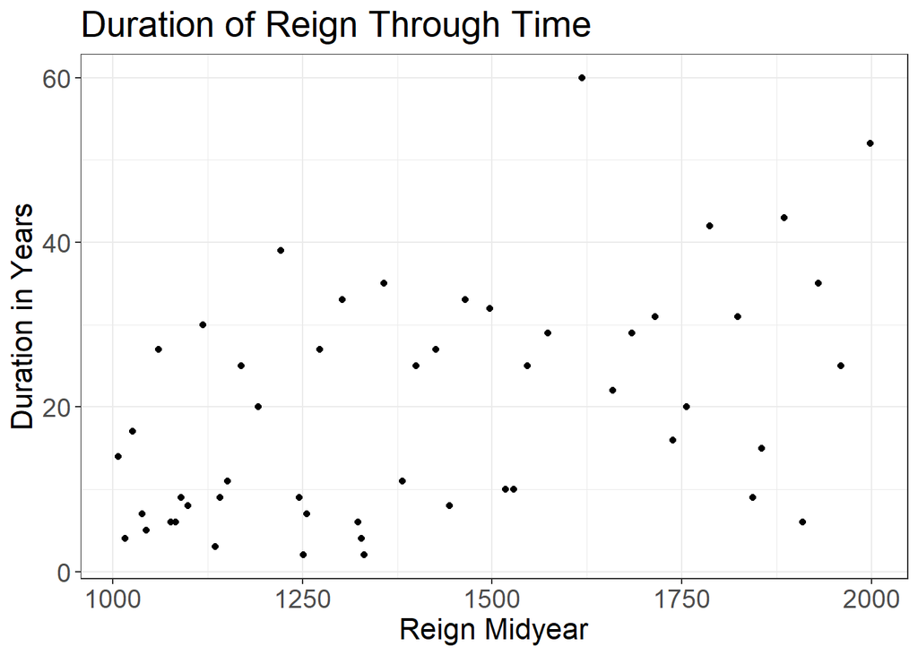

```r
kings_ggplot <- kings %>%
  mutate(midyear = start_reign_year + (end_reign_year - start_reign_year)/2)

kings_ggplot %>%
  ggplot(aes(x = midyear, y = duration)) +
  geom_point() +
  labs(title = "Duration of Reign Through Time", x = "Reign Midyear", y = "Duration in Years") +
  theme_bw() +
  theme(axis.text.x = element_text(size = 14),
        axis.text.y = element_text(size = 14),
        text = element_text(size = 16),
        plot.title = element_text(size = 20))
```

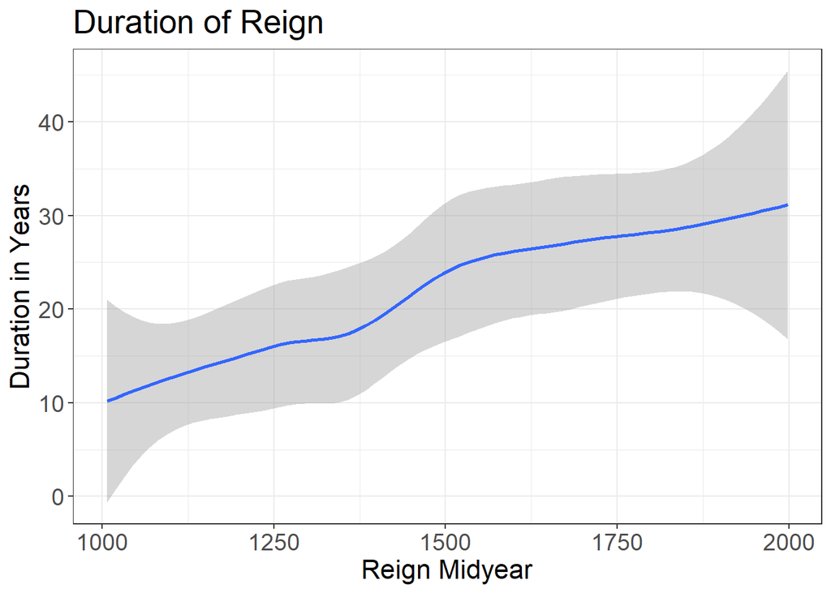

```r
kings_ggplot %>%
  ggplot(aes(x = midyear, y = duration)) +
  geom_smooth() +
  labs(title = "Duration of Reign", x = "Reign Midyear", y = "Duration in Years") +
  theme_bw() +
  theme(axis.text.x = element_text(size = 14),
        axis.text.y = element_text(size = 14),
        text = element_text(size = 16),
        plot.title = element_text(size = 20))
```